# UKB CVD: Phase 1 & Phase 2 First Occurrences Analysis, Baseline Characteristics and Initial Metabolite Exploration

2023-11-22

Author: M Janiczek Prepared for: R Balasubramanian & K Rexrode

## 0.1 Updates

Since last report, changed definition of Type 2 diabetes to only include ICD10 Code E11. Moved other diabetes codes into a new variable “Diabetes Other”. Also added Model 1 results and forest plots.

# 1 Summary

I also downloaded the aggregate “First Occurrences” data to determine if we should use that field for our outcome estimate.

# 2 Methods

By matching ICD10 codes (as described in the Said 2018 paper) in field 41270 (Hospital Inpatient records), as well as First Occurrences data (category 1712), I identified incident diagnosis of Hypertension, Type 2 Diabetes, Atrial Fibrilation, Stroke, and Coronary Artery Disease (CAD). I used the corresponding date of diagnoses and compared it to date of initial assessment (field 53) to identify diagnoses that occurred after first assessment. Some subjects had more than one condition, and all distnict diagnoses are included. In cases where a subject had multiple dates for the same diagnosis I used the first diagnosis date to compare to initial assessment at UKB assessment center.

I made a categorical variable “Metabolite Status” based on if subjects were included in the Phase I or Phase II metabolite release.

# 3 First occurrences data

First occurrences data (category 1712) were downloaded using Category 2409 “Circulatory system disorders” as well as category 2404 “Endocrine, nutritional and metabolic diseases” (for diabetes). The data fields included date the code was first recorded across primary care data, hospital inpatient data, death register records, or self-reported medical conditions reported at baseline or subsequent UK Biobank assessment centre visit, as well as the source of the code.

After downloading the data, I searched for fields containing the ICD10 codes previously discussed (from the Said 2018 paper), and created new variables for the 5 conditions, indicating “1” for patients who had that code AFTER the date of first UKB assessment, and 0 otherwise.

The following ICD10 codes were used to identify outcomes of interest (based on Appendix of Said 2018 paper):

[output not shown]

We determined we would go with only the first occurrences data for now as it appears to be cleaner.

# 4 Results

Below we can see the distribution of these codes from the various sources, which are largely still from hospital inpatient records:

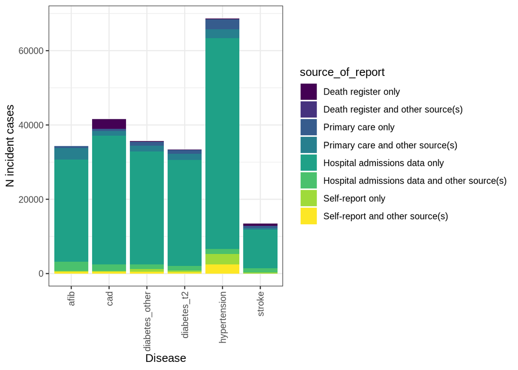

First, we can examine the distribution of incidence of our conditions of interest in the overall cohort compared to those in the PHase 1 cohort, split by Sex. The incidence is calculated using the first occurrences data (denoted with “FO” below).

[output not shown]

<sup>1</sup> n (%)

# 5 Summary of baseline characteristics

The below table describes the distribution of various baseline characteristics and measurements, defined as measured at the first date of assessment.

| **Characteristic** | All Samples **N** | All Samples **Overall**, N = 502,411<sup>1</sup> | All Samples **Female**, N = 273,325<sup>1</sup> | All Samples **Male**, N = 229,086<sup>1</sup> | Phase 1 **N** | Phase 1 **Overall**, N = 118,004<sup>1</sup> | Phase 1 **Female**, N = 63,913<sup>1</sup> | Phase 1 **Male**, N = 54,091<sup>1</sup> | Phase 2 **N** | Phase 2 **Overall**, N = 156,357<sup>1</sup> | Phase 2 **Female**, N = 84,152<sup>1</sup> | Phase 2 **Male**, N = 72,205<sup>1</sup> |
| --- | --- | --- | --- | --- | --- | --- | --- | --- | --- | --- | --- | --- |
| Baseline age (21003) | 502,411 | 58 (50, 63) | 57 (50, 63) | 58 (50, 64) | 118,004 | 58 (50, 63) | 57 (50, 63) | 58 (50, 64) | 156,357 | 58 (50, 63) | 58 (50, 63) | 58 (50, 64) |
| Height (cm) (50) | 499,870 | 168 (162, 175) | 162 (158, 167) | 176 (171, 180) | 117,703 | 168 (162, 175) | 162 (158, 167) | 176 (171, 180) | 155,919 | 168 (162, 175) | 162 (158, 167) | 175 (171, 180) |
| BMI (21001) | 499,304 | 26.7 (24.1, 29.9) | 26.1 (23.5, 29.7) | 27.3 (25.0, 30.1) | 117,572 | 26.8 (24.2, 29.9) | 26.1 (23.5, 29.7) | 27.3 (25.0, 30.1) | 155,762 | 26.8 (24.2, 29.9) | 26.2 (23.5, 29.8) | 27.3 (25.0, 30.1) |
| Waist circumference (cm) (48) | 500,248 | 90 (80, 99) | 83 (75, 92) | 96 (89, 103) | 117,778 | 90 (80, 99) | 83 (76, 92) | 96 (89, 103) | 156,026 | 90 (80, 99) | 83 (75, 92) | 96 (89, 103) |
| Hip circumference (cm) (49) | 500,189 | 102 (97, 108) | 102 (96, 109) | 103 (98, 107) | 117,770 | 102 (97, 108) | 102 (96, 109) | 103 (98, 107) | 156,011 | 102 (97, 108) | 102 (96, 108) | 103 (98, 107) |
| Bodyfat % (23099) | 492,003 | 31 (25, 38) | 37 (32, 41) | 25 (22, 29) | 115,863 | 31 (25, 38) | 37 (32, 41) | 25 (22, 29) | 153,268 | 31 (25, 38) | 37 (32, 42) | 25 (22, 29) |
| Trunk fat % (23127) | 491,981 | 31 (26, 37) | 35 (29, 40) | 28 (24, 32) | 115,857 | 31 (26, 37) | 35 (29, 40) | 28 (24, 32) | 153,246 | 31 (26, 37) | 35 (29, 40) | 28 (24, 32) |
| Whole body impedance (23106) | 492,224 | 595 (533, 663) | 652 (605, 701) | 534 (497, 573) | 115,923 | 595 (533, 663) | 652 (605, 700) | 534 (497, 574) | 153,342 | 594 (532, 663) | 653 (605, 701) | 534 (497, 573) |
| Current Smoker (1239) | 501,518 |  |  |  | 117,885 |  |  |  | 156,234 |  |  |  |
| Prefer not to answer |  | 428 (<0.1%) | 220 (<0.1%) | 208 (<0.1%) |  | 86 (<0.1%) | 48 (<0.1%) | 38 (<0.1%) |  | 127 (<0.1%) | 66 (<0.1%) | 61 (<0.1%) |
| No |  | 448,128 (89%) | 248,293 (91%) | 199,835 (87%) |  | 105,325 (89%) | 58,054 (91%) | 47,271 (87%) |  | 139,710 (89%) | 76,557 (91%) | 63,153 (88%) |
| Yes, on most or all days |  | 39,231 (7.8%) | 18,681 (6.8%) | 20,550 (9.0%) |  | 9,337 (7.9%) | 4,428 (6.9%) | 4,909 (9.1%) |  | 12,187 (7.8%) | 5,796 (6.9%) | 6,391 (8.9%) |
| Only occasionally |  | 13,731 (2.7%) | 5,680 (2.1%) | 8,051 (3.5%) |  | 3,137 (2.7%) | 1,321 (2.1%) | 1,816 (3.4%) |  | 4,210 (2.7%) | 1,671 (2.0%) | 2,539 (3.5%) |
| Had menopause | 272,849 |  |  |  | 63,849 |  |  |  | 84,085 |  |  |  |
| Prefer not to answer |  | 534 (0.2%) | 534 (0.2%) | 0 (NA%) |  | 132 (0.2%) | 132 (0.2%) | 0 (NA%) |  | 142 (0.2%) | 142 (0.2%) | 0 (NA%) |
| No |  | 64,043 (23%) | 64,043 (23%) | 0 (NA%) |  | 15,057 (24%) | 15,057 (24%) | 0 (NA%) |  | 19,305 (23%) | 19,305 (23%) | 0 (NA%) |
| Yes |  | 165,380 (61%) | 165,380 (61%) | 0 (NA%) |  | 38,592 (60%) | 38,592 (60%) | 0 (NA%) |  | 50,913 (61%) | 50,913 (61%) | 0 (NA%) |
| Not sure - had a hysterectomy |  | 31,165 (11%) | 31,165 (11%) | 0 (NA%) |  | 7,367 (12%) | 7,367 (12%) | 0 (NA%) |  | 10,124 (12%) | 10,124 (12%) | 0 (NA%) |
| Not sure - other reason |  | 11,727 (4.3%) | 11,727 (4.3%) | 0 (NA%) |  | 2,701 (4.2%) | 2,701 (4.2%) | 0 (NA%) |  | 3,601 (4.3%) | 3,601 (4.3%) | 0 (NA%) |
| Hysterectomy (ever) (3591) | 241,682 |  |  |  | 56,482 |  |  |  | 73,961 |  |  |  |
| Not sure |  | 257 (0.1%) | 257 (0.1%) | 0 (NA%) |  | 61 (0.1%) | 61 (0.1%) | 0 (NA%) |  | 72 (<0.1%) | 72 (<0.1%) | 0 (NA%) |
| Prefer not to answer |  | 272 (0.1%) | 272 (0.1%) | 0 (NA%) |  | 68 (0.1%) | 68 (0.1%) | 0 (NA%) |  | 72 (<0.1%) | 72 (<0.1%) | 0 (NA%) |
| No |  | 221,237 (92%) | 221,237 (92%) | 0 (NA%) |  | 51,767 (92%) | 51,767 (92%) | 0 (NA%) |  | 67,439 (91%) | 67,439 (91%) | 0 (NA%) |
| Yes |  | 19,916 (8.2%) | 19,916 (8.2%) | 0 (NA%) |  | 4,586 (8.1%) | 4,586 (8.1%) | 0 (NA%) |  | 6,378 (8.6%) | 6,378 (8.6%) | 0 (NA%) |
| Age at Hysterectomy (2824) | 51,031 | 43 (38, 49) | 43 (38, 49) | NA (NA, NA) | 11,934 | 43 (38, 49) | 43 (38, 49) | NA (NA, NA) | 16,493 | 43 (38, 49) | 43 (38, 49) | NA (NA, NA) |
| Pulse (automated) (102) | 467,984 | 68 (62, 76) | 69 (63, 77) | 67 (60, 76) | 110,939 | 68 (62, 76) | 69 (63, 77) | 67 (60, 76) | 147,604 | 68 (61, 76) | 69 (63, 77) | 67 (60, 76) |
| Diastolic BP (auto) (4079) | 467,984 | 82 (75, 89) | 80 (73, 88) | 84 (77, 91) | 110,939 | 82 (75, 89) | 80 (73, 87) | 84 (77, 91) | 147,604 | 82 (75, 89) | 80 (73, 87) | 84 (77, 91) |
| Systolic BP (auto) (4080) | 467,971 | 138 (126, 152) | 135 (122, 150) | 141 (130, 154) | 110,938 | 138 (126, 152) | 135 (122, 150) | 141 (130, 154) | 147,600 | 138 (126, 152) | 135 (123, 150) | 141 (130, 154) |
| Pulse during BP (manual) (95) | 33,102 | 70 (63, 78) | 71 (64, 78) | 69 (61, 78) | 6,939 | 70 (63, 78) | 70 (64, 78) | 69 (62, 77) | 8,573 | 70 (63, 78) | 70 (64, 78) | 69 (61, 78) |
| HbA1c (30750) | 466,414 | 35.2 (32.8, 37.9) | 35.2 (32.7, 37.7) | 35.3 (32.8, 38.1) | 112,524 | 35.2 (32.8, 37.9) | 35.2 (32.7, 37.7) | 35.3 (32.8, 38.1) | 148,631 | 35.3 (32.8, 37.9) | 35.2 (32.8, 37.7) | 35.3 (32.8, 38.1) |
| Ethnic Background (21000) | 501,511 |  |  |  | 117,885 |  |  |  | 156,232 |  |  |  |
| Prefer not to answer |  | 1,661 (0.3%) | 706 (0.3%) | 955 (0.4%) |  | 377 (0.3%) | 174 (0.3%) | 203 (0.4%) |  | 511 (0.3%) | 208 (0.2%) | 303 (0.4%) |
| Do not know |  | 217 (<0.1%) | 107 (<0.1%) | 110 (<0.1%) |  | 49 (<0.1%) | 21 (<0.1%) | 28 (<0.1%) |  | 48 (<0.1%) | 30 (<0.1%) | 18 (<0.1%) |
| White |  | 569 (0.1%) | 244 (<0.1%) | 325 (0.1%) |  | 121 (0.1%) | 53 (<0.1%) | 68 (0.1%) |  | 176 (0.1%) | 70 (<0.1%) | 106 (0.1%) |
| Mixed |  | 49 (<0.1%) | 30 (<0.1%) | 19 (<0.1%) |  | 8 (<0.1%) | 5 (<0.1%) | 3 (<0.1%) |  | 17 (<0.1%) | 12 (<0.1%) | 5 (<0.1%) |
| Asian or Asian British |  | 43 (<0.1%) | 23 (<0.1%) | 20 (<0.1%) |  | 11 (<0.1%) | 6 (<0.1%) | 5 (<0.1%) |  | 13 (<0.1%) | 6 (<0.1%) | 7 (<0.1%) |
| Black or Black British |  | 27 (<0.1%) | 18 (<0.1%) | 9 (<0.1%) |  | 7 (<0.1%) | 5 (<0.1%) | 2 (<0.1%) |  | 6 (<0.1%) | 4 (<0.1%) | 2 (<0.1%) |
| Chinese |  | 1,573 (0.3%) | 989 (0.4%) | 584 (0.3%) |  | 344 (0.3%) | 214 (0.3%) | 130 (0.2%) |  | 466 (0.3%) | 285 (0.3%) | 181 (0.3%) |
| Other ethnic group |  | 4,557 (0.9%) | 2,595 (1.0%) | 1,962 (0.9%) |  | 1,046 (0.9%) | 600 (0.9%) | 446 (0.8%) |  | 1,264 (0.8%) | 690 (0.8%) | 574 (0.8%) |
| British |  | 442,516 (88%) | 240,213 (88%) | 202,303 (88%) |  | 104,268 (88%) | 56,374 (88%) | 47,894 (89%) |  | 139,810 (89%) | 75,262 (90%) | 64,548 (89%) |
| Irish |  | 13,201 (2.6%) | 6,894 (2.5%) | 6,307 (2.8%) |  | 3,082 (2.6%) | 1,599 (2.5%) | 1,483 (2.7%) |  | 3,938 (2.5%) | 2,008 (2.4%) | 1,930 (2.7%) |
| Any other white background |  | 16,326 (3.3%) | 10,037 (3.7%) | 6,289 (2.8%) |  | 3,822 (3.2%) | 2,303 (3.6%) | 1,519 (2.8%) |  | 4,471 (2.9%) | 2,669 (3.2%) | 1,802 (2.5%) |
| White and Black Caribbean |  | 619 (0.1%) | 389 (0.1%) | 230 (0.1%) |  | 130 (0.1%) | 81 (0.1%) | 49 (<0.1%) |  | 194 (0.1%) | 112 (0.1%) | 82 (0.1%) |
| White and Black African |  | 425 (<0.1%) | 296 (0.1%) | 129 (<0.1%) |  | 100 (<0.1%) | 66 (0.1%) | 34 (<0.1%) |  | 123 (<0.1%) | 85 (0.1%) | 38 (<0.1%) |
| White and Asian |  | 830 (0.2%) | 482 (0.2%) | 348 (0.2%) |  | 197 (0.2%) | 108 (0.2%) | 89 (0.2%) |  | 211 (0.1%) | 124 (0.1%) | 87 (0.1%) |
| Any other mixed background |  | 1,031 (0.2%) | 653 (0.2%) | 378 (0.2%) |  | 231 (0.2%) | 154 (0.2%) | 77 (0.1%) |  | 307 (0.2%) | 174 (0.2%) | 133 (0.2%) |
| Indian |  | 5,951 (1.2%) | 2,939 (1.1%) | 3,012 (1.3%) |  | 1,371 (1.2%) | 659 (1.0%) | 712 (1.3%) |  | 1,532 (1.0%) | 740 (0.9%) | 792 (1.1%) |
| Pakistani |  | 1,835 (0.4%) | 715 (0.3%) | 1,120 (0.5%) |  | 440 (0.4%) | 181 (0.3%) | 259 (0.5%) |  | 558 (0.4%) | 194 (0.2%) | 364 (0.5%) |
| Bangladeshi |  | 236 (<0.1%) | 74 (<0.1%) | 162 (<0.1%) |  | 61 (<0.1%) | 16 (<0.1%) | 45 (<0.1%) |  | 59 (<0.1%) | 22 (<0.1%) | 37 (<0.1%) |
| Any other Asian background |  | 1,814 (0.4%) | 834 (0.3%) | 980 (0.4%) |  | 435 (0.4%) | 193 (0.3%) | 242 (0.4%) |  | 449 (0.3%) | 204 (0.2%) | 245 (0.3%) |
| Caribbean |  | 4,515 (0.9%) | 2,868 (1.1%) | 1,647 (0.7%) |  | 1,007 (0.9%) | 659 (1.0%) | 348 (0.6%) |  | 1,178 (0.8%) | 738 (0.9%) | 440 (0.6%) |
| African |  | 3,393 (0.7%) | 1,685 (0.6%) | 1,708 (0.7%) |  | 757 (0.6%) | 365 (0.6%) | 392 (0.7%) |  | 872 (0.6%) | 434 (0.5%) | 438 (0.6%) |
| Any other Black background |  | 123 (<0.1%) | 81 (<0.1%) | 42 (<0.1%) |  | 21 (<0.1%) | 15 (<0.1%) | 6 (<0.1%) |  | 29 (<0.1%) | 18 (<0.1%) | 11 (<0.1%) |

<sup>1</sup> Median (IQR); n (%)

For the models, we stratify by age in the following strata <50, 50-59, 60-69, 70-85. See below for distribution of participants by phase, sex, and age category.

| **Characteristic** | **All Samples** **Overall**, N = 502,411<sup>1</sup> | **All Samples** **Female**, N = 273,325<sup>1</sup> | **All Samples** **Male**, N = 229,086<sup>1</sup> | **Phase 1 Samples** **Overall**, N = 118,004<sup>1</sup> | **Phase 1 Samples** **Female**, N = 63,913<sup>1</sup> | **Phase 1 Samples** **Male**, N = 54,091<sup>1</sup> | **Phase 2 Samples** **Overall**, N = 156,357<sup>1</sup> | **Phase 2 Samples** **Female**, N = 84,152<sup>1</sup> | **Phase 2 Samples** **Male**, N = 72,205<sup>1</sup> |
| --- | --- | --- | --- | --- | --- | --- | --- | --- | --- |
| age_cat |  |  |  |  |  |  |  |  |  |
| <50 | 117,829 (23%) | 64,639 (24%) | 53,190 (23%) | 27,678 (23%) | 15,079 (24%) | 12,599 (23%) | 36,233 (23%) | 19,532 (23%) | 16,701 (23%) |
| 50-59 | 167,113 (33%) | 94,003 (34%) | 73,110 (32%) | 39,278 (33%) | 21,992 (34%) | 17,286 (32%) | 51,735 (33%) | 28,816 (34%) | 22,919 (32%) |
| 60-69 | 215,045 (43%) | 113,496 (42%) | 101,549 (44%) | 50,509 (43%) | 26,596 (42%) | 23,913 (44%) | 67,631 (43%) | 35,431 (42%) | 32,200 (45%) |
| 70-85 | 2,424 (0.5%) | 1,187 (0.4%) | 1,237 (0.5%) | 539 (0.5%) | 246 (0.4%) | 293 (0.5%) | 758 (0.5%) | 373 (0.4%) | 385 (0.5%) |

<sup>1</sup> n (%)

# 6 Initial Metabolite exploration

All 249 metabolites had some sort of measurement (>0) 99.9% of the Phase I samples. I used the updated Phase I data released with Phase II.

## 6.1 M1 (Minimal Model): Age Stratified + Menopause

Outcome: Metabolite level Exposure: Sex

Age split into following strata: <50, 50-59, 60-69, 70-85. Linear regression model of for each metabolite fit within each strata. Centered and scaled metabolite value so that we could compare coefficients easier.

$CenteredScaled Metabolite Value \sim Sex + Menopause*$

- Menopausal status: “Not sure” but over 55 goes into “Menopausal”. Under 55 go into category “Undetermined”. Variable only used in the <50 and 50-59 strata.

Within each age strata, fit the M1 for all metabolites and get p-values for exposure. Do FDR adjustment for multiple testing; use q <0.05.

| **Characteristic** | **Overall**, N = 502,411<sup>1</sup> | **White**, N = 472,612<sup>1</sup> | **Black**, N = 8,058<sup>1</sup> | **Southeast Asian**, N = 8,022<sup>1</sup> | **Asian**, N = 3,430<sup>1</sup> | **Other**, N = 4,557<sup>1</sup> | **Mixed**, N = 2,954<sup>1</sup> | **Unknown**, N = 2,778<sup>1</sup> |
| --- | --- | --- | --- | --- | --- | --- | --- | --- |
| Ethnic Background (21000) |  |  |  |  |  |  |  |  |
| Prefer not to answer | 1,661 (0.3%) | 0 (0%) | 0 (0%) | 0 (0%) | 0 (0%) | 0 (0%) | 0 (0%) | 1,661 (88%) |
| Do not know | 217 (<0.1%) | 0 (0%) | 0 (0%) | 0 (0%) | 0 (0%) | 0 (0%) | 0 (0%) | 217 (12%) |
| White | 569 (0.1%) | 569 (0.1%) | 0 (0%) | 0 (0%) | 0 (0%) | 0 (0%) | 0 (0%) | 0 (0%) |
| Mixed | 49 (<0.1%) | 0 (0%) | 0 (0%) | 0 (0%) | 0 (0%) | 0 (0%) | 49 (1.7%) | 0 (0%) |
| Asian or Asian British | 43 (<0.1%) | 0 (0%) | 0 (0%) | 0 (0%) | 43 (1.3%) | 0 (0%) | 0 (0%) | 0 (0%) |
| Black or Black British | 27 (<0.1%) | 0 (0%) | 27 (0.3%) | 0 (0%) | 0 (0%) | 0 (0%) | 0 (0%) | 0 (0%) |
| Chinese | 1,573 (0.3%) | 0 (0%) | 0 (0%) | 0 (0%) | 1,573 (46%) | 0 (0%) | 0 (0%) | 0 (0%) |
| Other ethnic group | 4,557 (0.9%) | 0 (0%) | 0 (0%) | 0 (0%) | 0 (0%) | 4,557 (100%) | 0 (0%) | 0 (0%) |
| British | 442,516 (88%) | 442,516 (94%) | 0 (0%) | 0 (0%) | 0 (0%) | 0 (0%) | 0 (0%) | 0 (0%) |
| Irish | 13,201 (2.6%) | 13,201 (2.8%) | 0 (0%) | 0 (0%) | 0 (0%) | 0 (0%) | 0 (0%) | 0 (0%) |
| Any other white background | 16,326 (3.3%) | 16,326 (3.5%) | 0 (0%) | 0 (0%) | 0 (0%) | 0 (0%) | 0 (0%) | 0 (0%) |
| White and Black Caribbean | 619 (0.1%) | 0 (0%) | 0 (0%) | 0 (0%) | 0 (0%) | 0 (0%) | 619 (21%) | 0 (0%) |
| White and Black African | 425 (<0.1%) | 0 (0%) | 0 (0%) | 0 (0%) | 0 (0%) | 0 (0%) | 425 (14%) | 0 (0%) |
| White and Asian | 830 (0.2%) | 0 (0%) | 0 (0%) | 0 (0%) | 0 (0%) | 0 (0%) | 830 (28%) | 0 (0%) |
| Any other mixed background | 1,031 (0.2%) | 0 (0%) | 0 (0%) | 0 (0%) | 0 (0%) | 0 (0%) | 1,031 (35%) | 0 (0%) |
| Indian | 5,951 (1.2%) | 0 (0%) | 0 (0%) | 5,951 (74%) | 0 (0%) | 0 (0%) | 0 (0%) | 0 (0%) |
| Pakistani | 1,835 (0.4%) | 0 (0%) | 0 (0%) | 1,835 (23%) | 0 (0%) | 0 (0%) | 0 (0%) | 0 (0%) |
| Bangladeshi | 236 (<0.1%) | 0 (0%) | 0 (0%) | 236 (2.9%) | 0 (0%) | 0 (0%) | 0 (0%) | 0 (0%) |
| Any other Asian background | 1,814 (0.4%) | 0 (0%) | 0 (0%) | 0 (0%) | 1,814 (53%) | 0 (0%) | 0 (0%) | 0 (0%) |
| Caribbean | 4,515 (0.9%) | 0 (0%) | 4,515 (56%) | 0 (0%) | 0 (0%) | 0 (0%) | 0 (0%) | 0 (0%) |
| African | 3,393 (0.7%) | 0 (0%) | 3,393 (42%) | 0 (0%) | 0 (0%) | 0 (0%) | 0 (0%) | 0 (0%) |
| Any other Black background | 123 (<0.1%) | 0 (0%) | 123 (1.5%) | 0 (0%) | 0 (0%) | 0 (0%) | 0 (0%) | 0 (0%) |
| Unknown | 900 | 0 | 0 | 0 | 0 | 0 | 0 | 900 |

<sup>1</sup> n (%)

Phase I Metabolites q <0.05 and abs(estimate)>0.5

| metabolite | age_cat | term | estimate | std.error | statistic | p.value | conf.low | conf.high | fdr | phase | met_threshold |
| --- | --- | --- | --- | --- | --- | --- | --- | --- | --- | --- | --- |
| hdl_cholesterol_f23406_0_0 | 50-59 | sex.L | -0.6197405 | 0.012835093 | -48.284850 | 0.000000e+00 | -0.6448976 | -0.5945834 | 0.000000e+00 | Phase I | TRUE |
| phospholipids_in_hdl_f23414_0_0 | 50-59 | sex.L | -0.5736292 | 0.012926811 | -44.375155 | 0.000000e+00 | -0.5989661 | -0.5482924 | 0.000000e+00 | Phase I | TRUE |
| cholesteryl_esters_in_hdl_f23418_0_0 | 50-59 | sex.L | -0.6161357 | 0.012886367 | -47.812987 | 0.000000e+00 | -0.6413933 | -0.5908781 | 0.000000e+00 | Phase I | TRUE |
| free_cholesterol_in_hdl_f23422_0_0 | 50-59 | sex.L | -0.6127373 | 0.012726248 | -48.147520 | 0.000000e+00 | -0.6376811 | -0.5877935 | 0.000000e+00 | Phase I | TRUE |
| total_lipids_in_hdl_f23426_0_0 | 50-59 | sex.L | -0.5895229 | 0.012858926 | -45.845425 | 0.000000e+00 | -0.6147267 | -0.5643191 | 0.000000e+00 | Phase I | TRUE |
| average_diameter_for_vldl_particles_f23431_0_0 | 50-59 | sex.L | 0.6176154 | 0.013020681 | 47.433420 | 0.000000e+00 | 0.5920946 | 0.6431363 | 0.000000e+00 | Phase I | TRUE |
| average_diameter_for_hdl_particles_f23433_0_0 | 50-59 | sex.L | -0.7084749 | 0.012619092 | -56.143097 | 0.000000e+00 | -0.7332086 | -0.6837412 | 0.000000e+00 | Phase I | TRUE |
| triglycerides_to_phosphoglycerides_ratio_f23435_0_0 | 50-59 | sex.L | 0.5989507 | 0.013169646 | 45.479632 | 0.000000e+00 | 0.5731378 | 0.6247635 | 0.000000e+00 | Phase I | TRUE |
| apolipoprotein_a1_f23440_0_0 | 50-59 | sex.L | -0.5188340 | 0.013020326 | -39.848006 | 0.000000e+00 | -0.5443542 | -0.4933139 | 0.000000e+00 | Phase I | TRUE |
| creatinine_f23478_0_0 | 50-59 | sex.L | 0.6673884 | 0.012122754 | 55.052539 | 0.000000e+00 | 0.6436275 | 0.6911493 | 0.000000e+00 | Phase I | TRUE |
| concentration_of_very_large_hdl_particles_f23551_0_0 | 50-59 | sex.L | -0.5953141 | 0.012935694 | -46.021043 | 0.000000e+00 | -0.6206684 | -0.5699598 | 0.000000e+00 | Phase I | TRUE |
| total_lipids_in_very_large_hdl_f23552_0_0 | 50-59 | sex.L | -0.6294495 | 0.012943773 | -48.629527 | 0.000000e+00 | -0.6548197 | -0.6040794 | 0.000000e+00 | Phase I | TRUE |
| phospholipids_in_very_large_hdl_f23553_0_0 | 50-59 | sex.L | -0.6432350 | 0.012949164 | -49.673864 | 0.000000e+00 | -0.6686157 | -0.6178543 | 0.000000e+00 | Phase I | TRUE |
| cholesterol_in_very_large_hdl_f23554_0_0 | 50-59 | sex.L | -0.6165724 | 0.012964910 | -47.557016 | 0.000000e+00 | -0.6419840 | -0.5911609 | 0.000000e+00 | Phase I | TRUE |
| cholesteryl_esters_in_very_large_hdl_f23555_0_0 | 50-59 | sex.L | -0.6308535 | 0.012920967 | -48.824011 | 0.000000e+00 | -0.6561789 | -0.6055280 | 0.000000e+00 | Phase I | TRUE |
| free_cholesterol_in_very_large_hdl_f23556_0_0 | 50-59 | sex.L | -0.5385669 | 0.013197079 | -40.809553 | 0.000000e+00 | -0.5644335 | -0.5127003 | 0.000000e+00 | Phase I | TRUE |
| concentration_of_large_hdl_particles_f23558_0_0 | 50-59 | sex.L | -0.6751025 | 0.012734592 | -53.013284 | 0.000000e+00 | -0.7000627 | -0.6501424 | 0.000000e+00 | Phase I | TRUE |
| total_lipids_in_large_hdl_f23559_0_0 | 50-59 | sex.L | -0.6834975 | 0.012747137 | -53.619691 | 0.000000e+00 | -0.7084822 | -0.6585128 | 0.000000e+00 | Phase I | TRUE |
| phospholipids_in_large_hdl_f23560_0_0 | 50-59 | sex.L | -0.6860019 | 0.012746427 | -53.819156 | 0.000000e+00 | -0.7109852 | -0.6610186 | 0.000000e+00 | Phase I | TRUE |
| cholesterol_in_large_hdl_f23561_0_0 | 50-59 | sex.L | -0.6782792 | 0.012797056 | -53.002751 | 0.000000e+00 | -0.7033617 | -0.6531966 | 0.000000e+00 | Phase I | TRUE |
| cholesteryl_esters_in_large_hdl_f23562_0_0 | 50-59 | sex.L | -0.6761447 | 0.012821788 | -52.734039 | 0.000000e+00 | -0.7012757 | -0.6510137 | 0.000000e+00 | Phase I | TRUE |
| free_cholesterol_in_large_hdl_f23563_0_0 | 50-59 | sex.L | -0.6797627 | 0.012733535 | -53.383660 | 0.000000e+00 | -0.7047207 | -0.6548046 | 0.000000e+00 | Phase I | TRUE |
| concentration_of_medium_hdl_particles_f23565_0_0 | 50-59 | sex.L | -0.5158223 | 0.013105710 | -39.358589 | 0.000000e+00 | -0.5415098 | -0.4901348 | 0.000000e+00 | Phase I | TRUE |
| cholesterol_in_medium_hdl_f23568_0_0 | 50-59 | sex.L | -0.5429886 | 0.013100478 | -41.448000 | 0.000000e+00 | -0.5686659 | -0.5173113 | 0.000000e+00 | Phase I | TRUE |
| cholesteryl_esters_in_medium_hdl_f23569_0_0 | 50-59 | sex.L | -0.5382180 | 0.013139897 | -40.960594 | 0.000000e+00 | -0.5639725 | -0.5124635 | 0.000000e+00 | Phase I | TRUE |
| free_cholesterol_in_medium_hdl_f23570_0_0 | 50-59 | sex.L | -0.5498448 | 0.012972840 | -42.384300 | 0.000000e+00 | -0.5752718 | -0.5244177 | 0.000000e+00 | Phase I | TRUE |
| phospholipids_to_total_lipids_in_very_large_hdl_percentage_f23629_0_0 | 50-59 | sex.L | -0.5940232 | 0.012875435 | -46.136163 | 0.000000e+00 | -0.6192593 | -0.5687870 | 0.000000e+00 | Phase I | TRUE |
| free_cholesterol_to_total_lipids_in_very_large_hdl_percentage_f23632_0_0 | 50-59 | sex.L | 0.6388449 | 0.012359077 | 51.690342 | 0.000000e+00 | 0.6146208 | 0.6630690 | 0.000000e+00 | Phase I | TRUE |
| free_cholesterol_to_total_lipids_in_medium_hdl_percentage_f23642_0_0 | 50-59 | sex.L | -0.6241983 | 0.012398064 | -50.346434 | 0.000000e+00 | -0.6484988 | -0.5998978 | 0.000000e+00 | Phase I | TRUE |
| hdl_cholesterol_f23406_0_0 | <50 | sex.L | -0.5956708 | 0.007729995 | -77.059669 | 0.000000e+00 | -0.6108220 | -0.5805197 | 0.000000e+00 | Phase I | TRUE |

[output cut: 155 more lines]

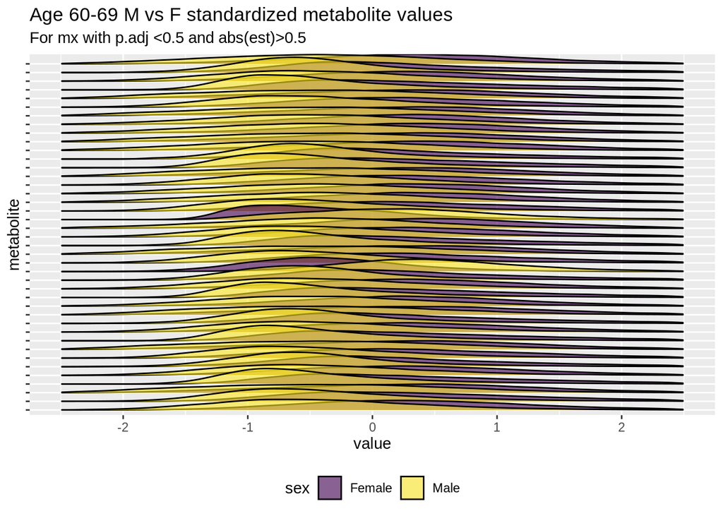

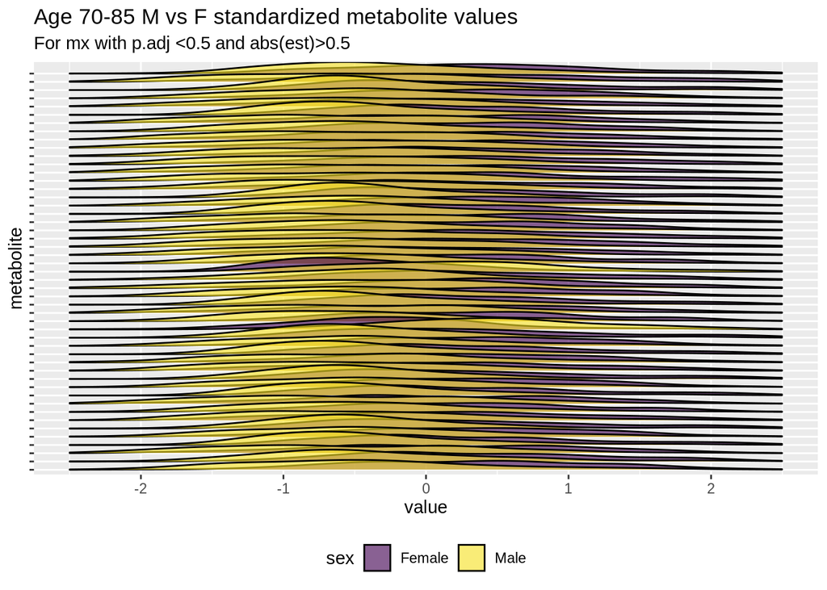

## 6.2 Phase II M1

```
## [1] 83
```

```
## [1] "<50"   "50-59" "60-69" "70-85"
```

## 6.3 Summarizing M1 Results

Below I summarize which of the metabolites in Phase I which met the threshold of having BOTH FDR-adjusted pvalue < 0.05 AND an absolute value estimate in the model of >0.5 also met the same threshold criteria in Phase II data.

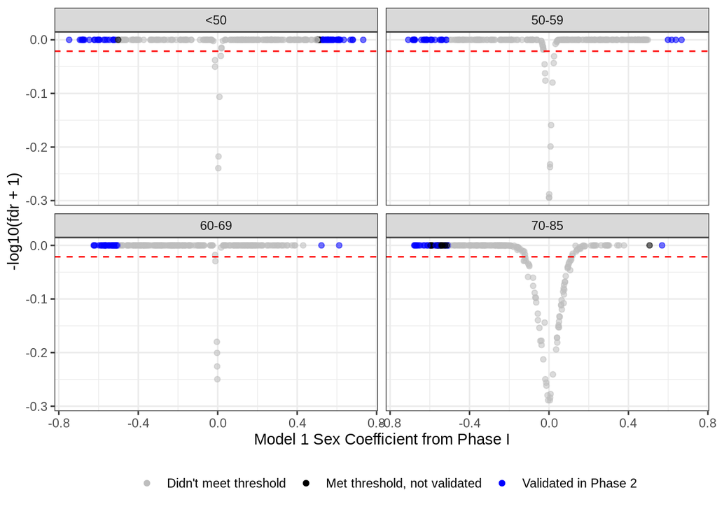

|  | sig_category Didn’t meet threshold | sig_category Met threshold, not validated | sig_category Validated in Phase 2 | Total |  |
| --- | --- | --- | --- | --- | --- |
| age_cat |  |  |  |  |  |
| <50 | 183 | 8 | 58 | 249 |  |
| 50-59 | 220 | 0 | 29 | 249 |  |
| 60-69 | 208 | 0 | 41 | 249 |  |
| 70-85 | 200 | 18 | 31 | 249 |  |
| Total | 811 | 26 | 159 | 996 |  |

number of unique metabolites that met the threshold in Phase I

```
## [1] 92
```

number of unique validated metabolites where the metabolite met the thresholds in both phase 1 and phase 2. Saved table of these 81 unique metabolites and their metabolite group and subgroup (validated_unique_mets_81_details.csv).

```
## [1] 81
```

## 6.4 Forest plots

Bars denote effect size in direction for metabolites from M1 that had FDR <0.05. (Bar is 0 if FDR >0.05).

### 6.4.1 Forest plots by metabolite group (excluding Lipoproteins)

```
##  [1] "Cholesterol"                         "Phospholipids"
##  [3] "Cholesteryl esters"                  "Free cholesterol"
##  [5] "Total lipids"                        "Lipoprotein particle sizes"
##  [7] NA                                    "Apolipoproteins"
##  [9] "Fluid balance"                       "Lipoprotein subclasses"
## [11] "Triglycerides"                       "Amino acids"
## [13] "Lipoprotein particle concentrations" "Other lipids"
## [15] "Fatty acids"
```

```
##                         Amino acids                     Apolipoproteins
##                                   1                                   3
##                         Cholesterol                  Cholesteryl esters
##                                   6                                   6
##                         Fatty acids                       Fluid balance
##                                   2                                   4
##                    Free cholesterol Lipoprotein particle concentrations
##                                   6                                   4
##          Lipoprotein particle sizes              Lipoprotein subclasses
##                                   6                                 104
##                        Other lipids                       Phospholipids
##                                   8                                   7
##                        Total lipids                       Triglycerides
##                                   6                                   2
##                                NA's
##                                  20
```

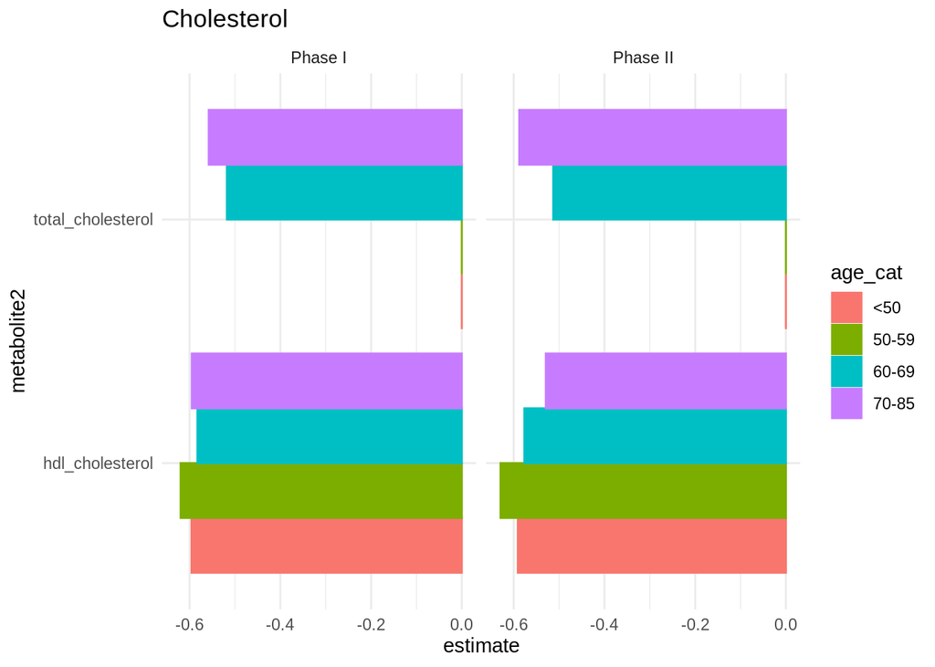

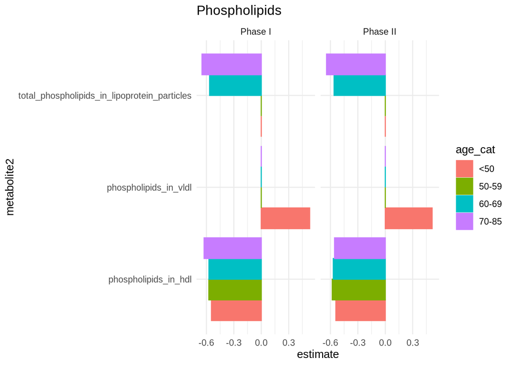

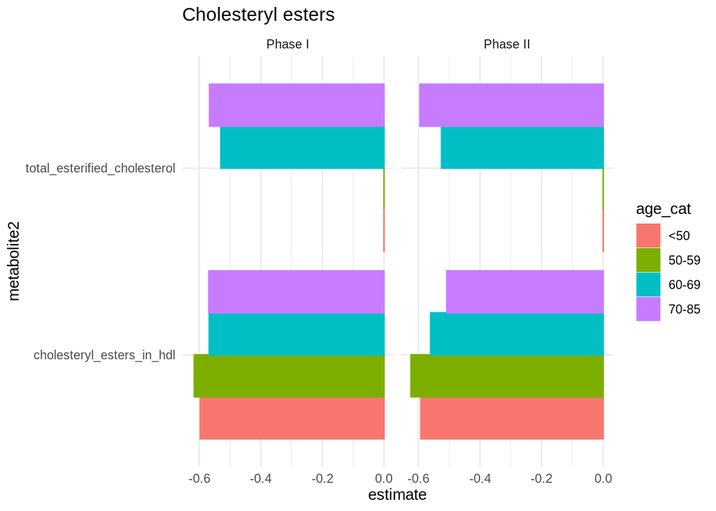

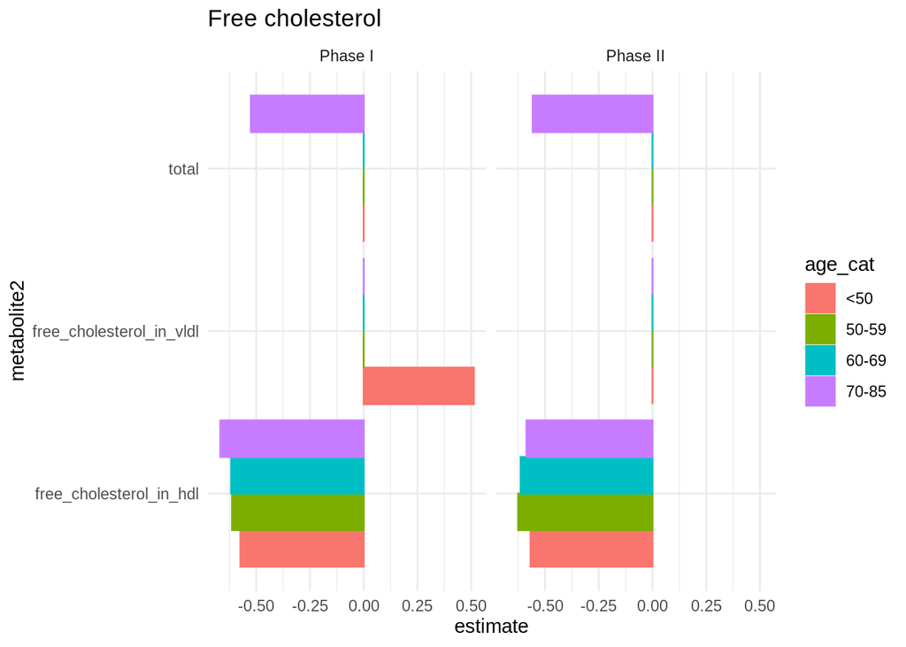

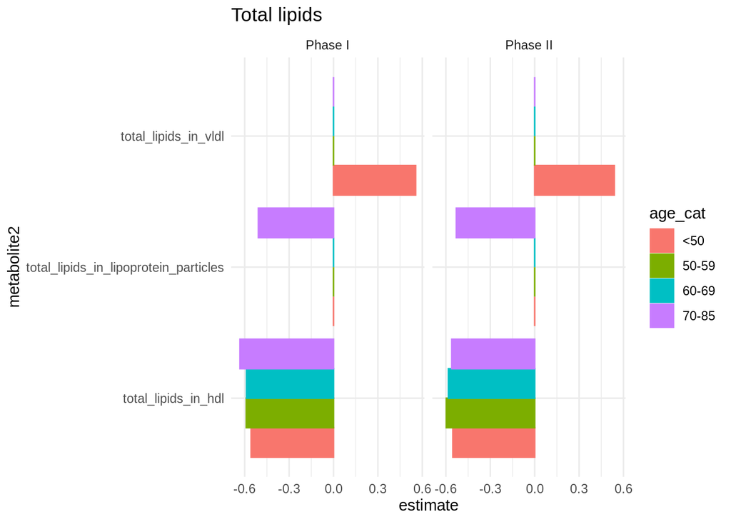

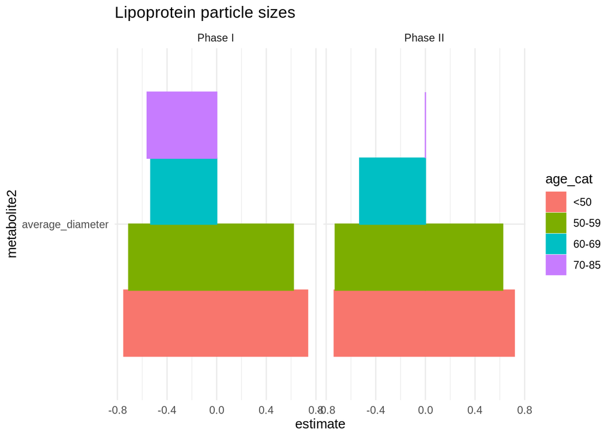

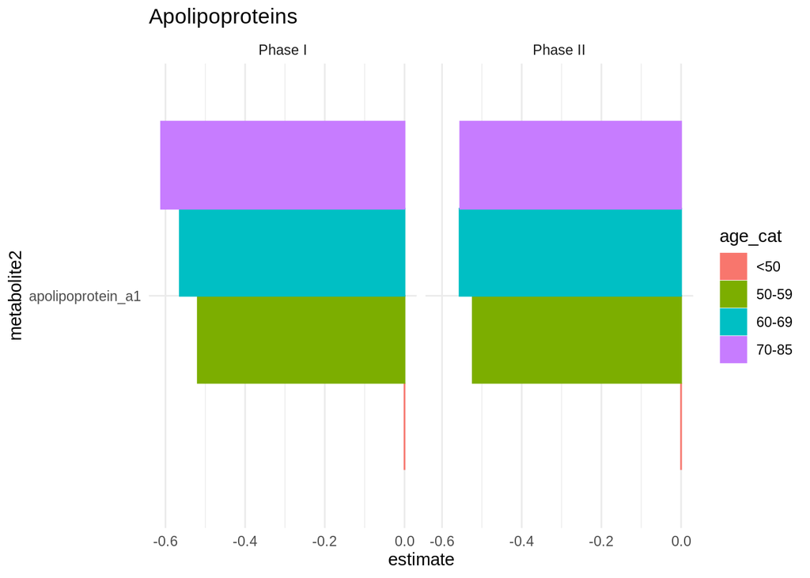

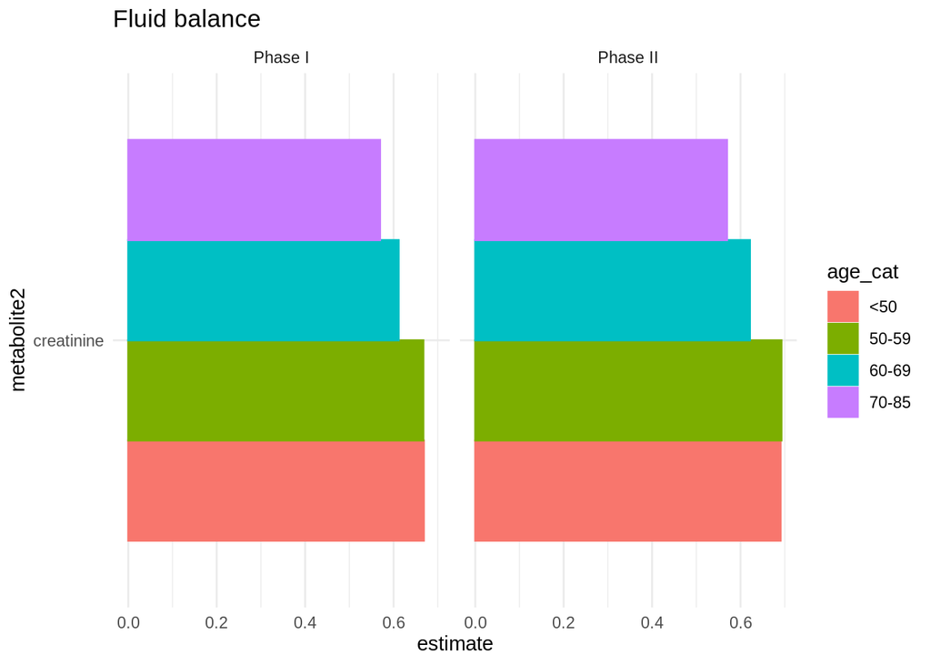

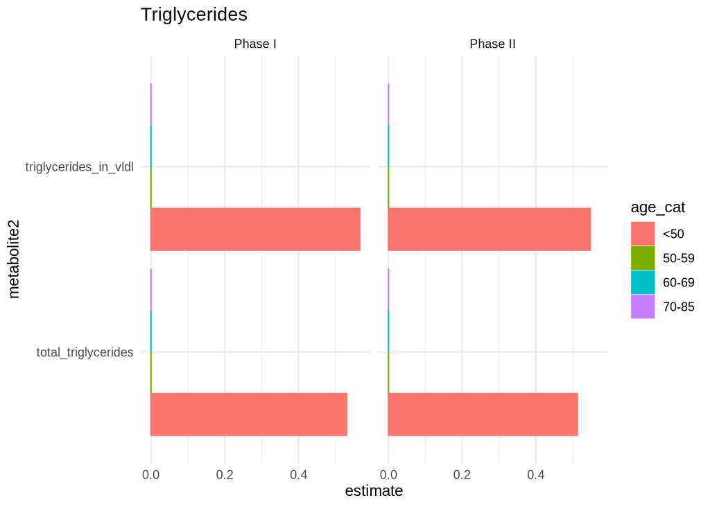

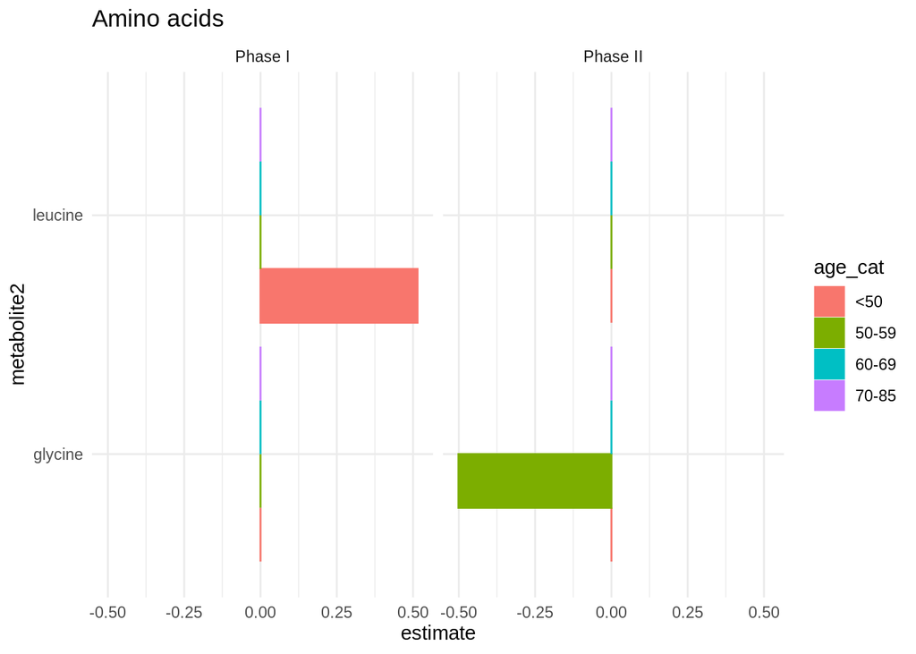

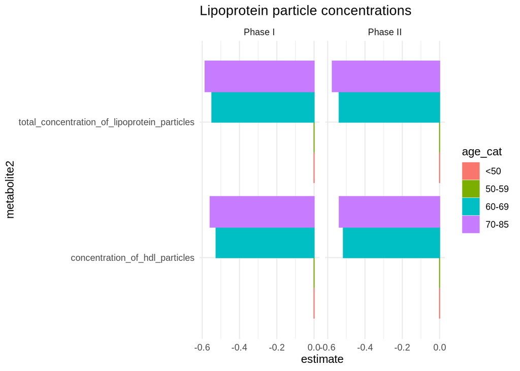

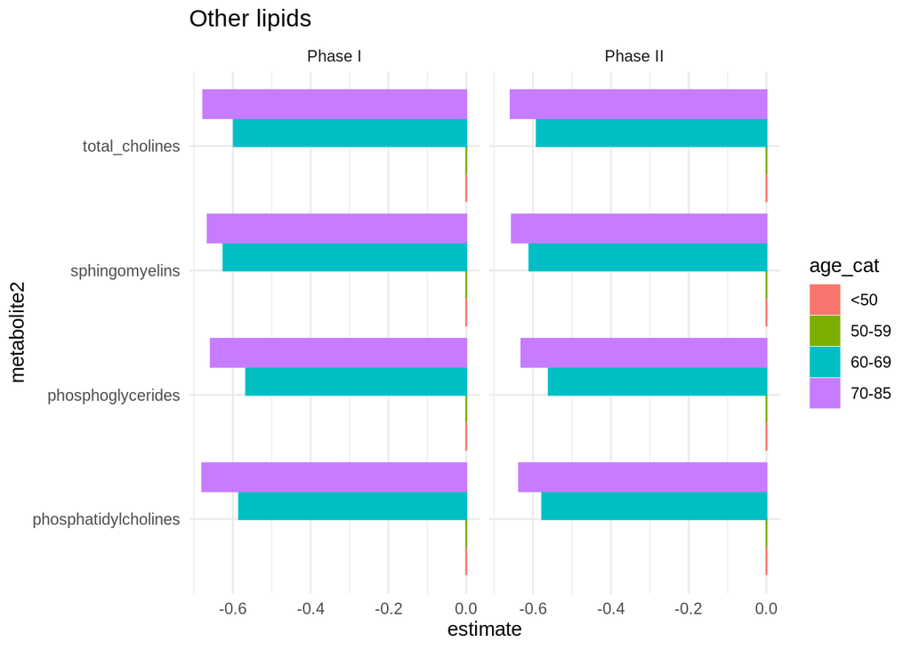

[1 more figures not shown]

### 6.4.2 Forest Plots For Lipoprotein subclasses

There were 14 unique Lipoprotein subclasses within the dataset. 11 of them had significant metabolites from M1 and I plot these separately below.

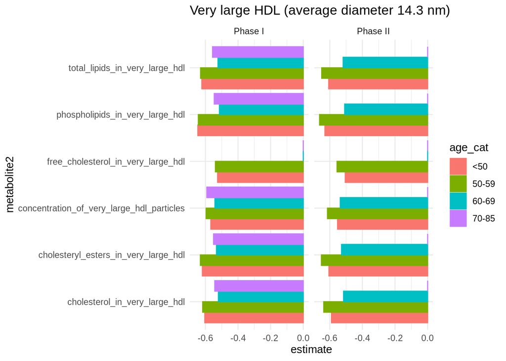

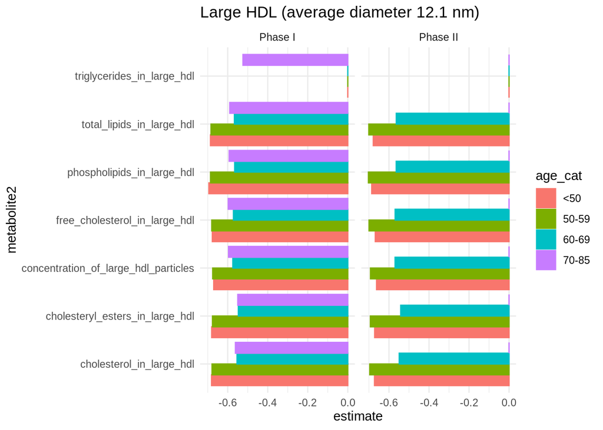

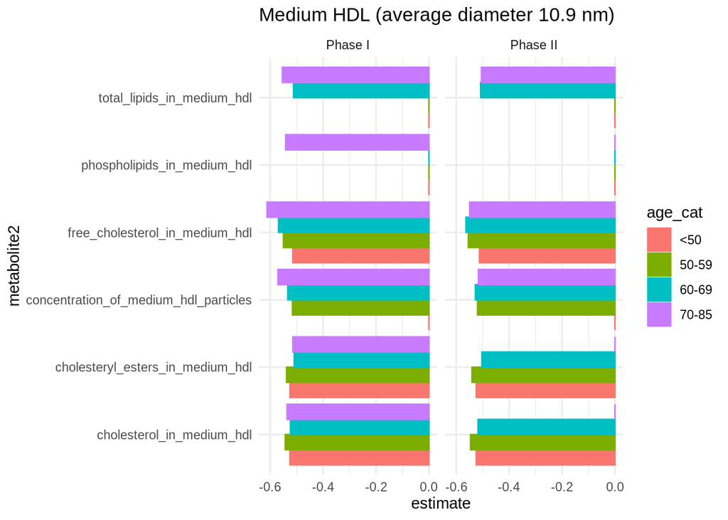

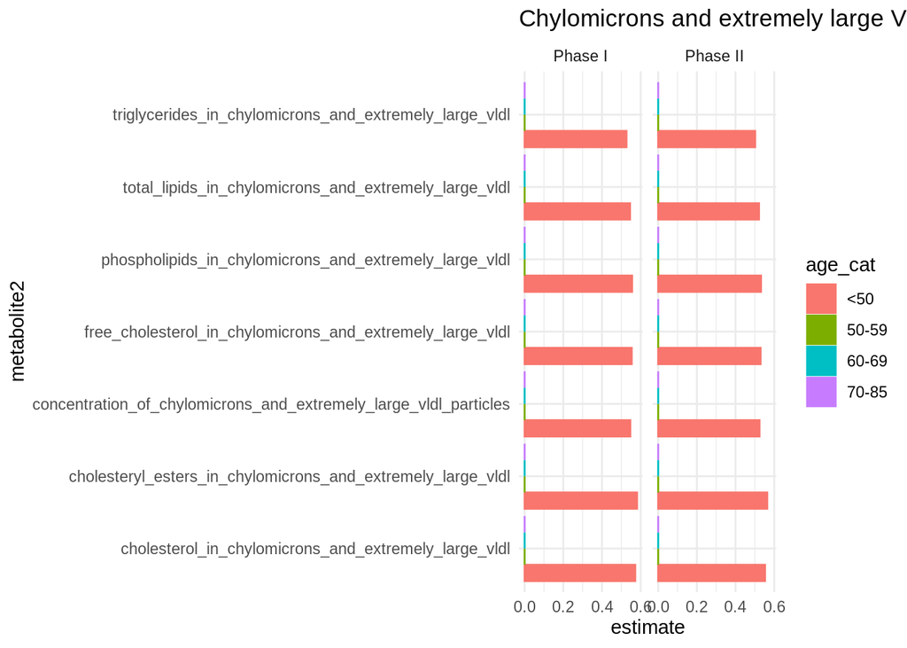

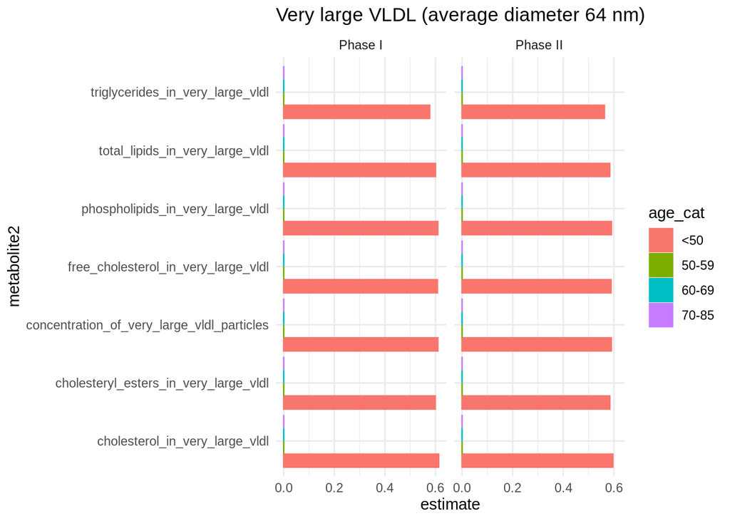

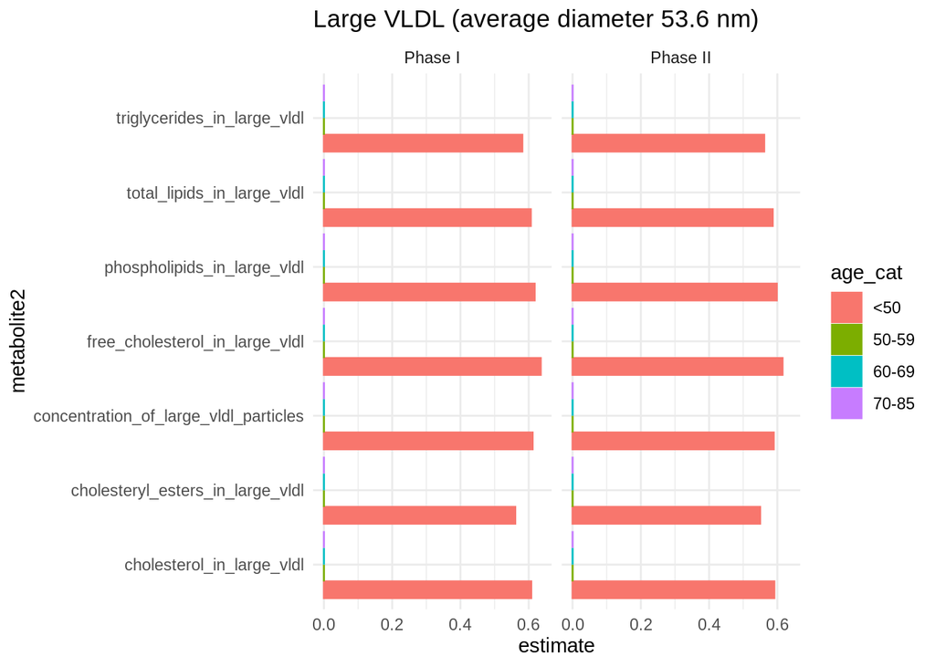

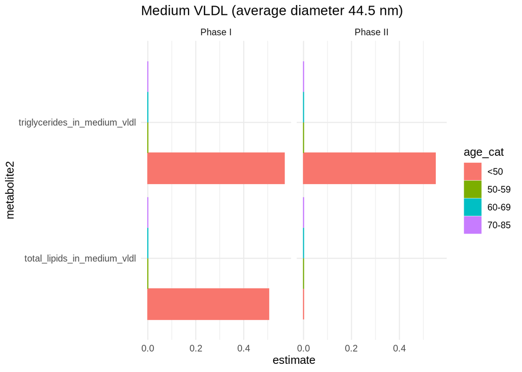

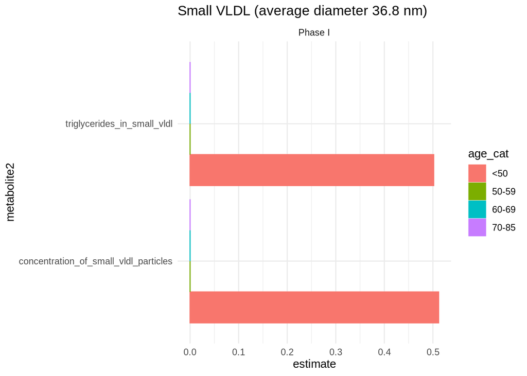

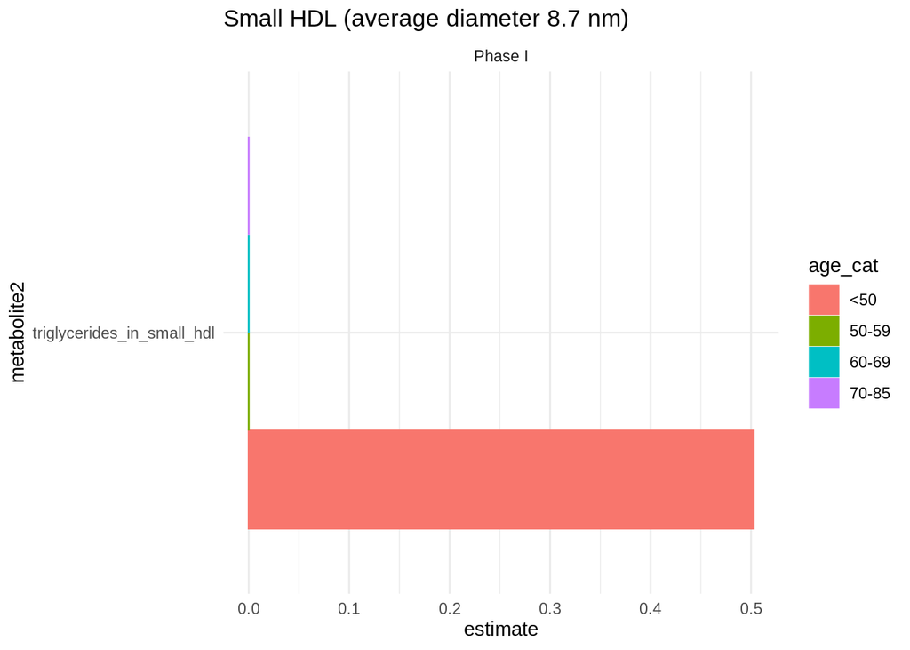

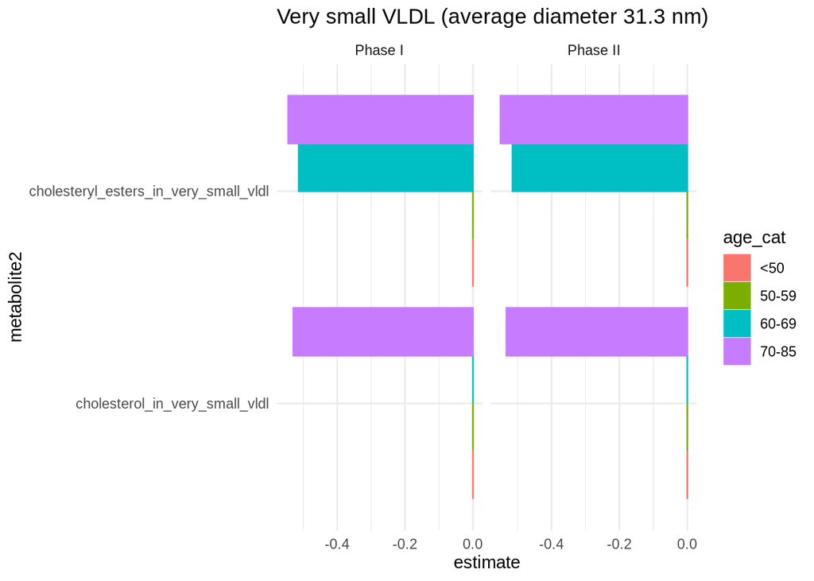

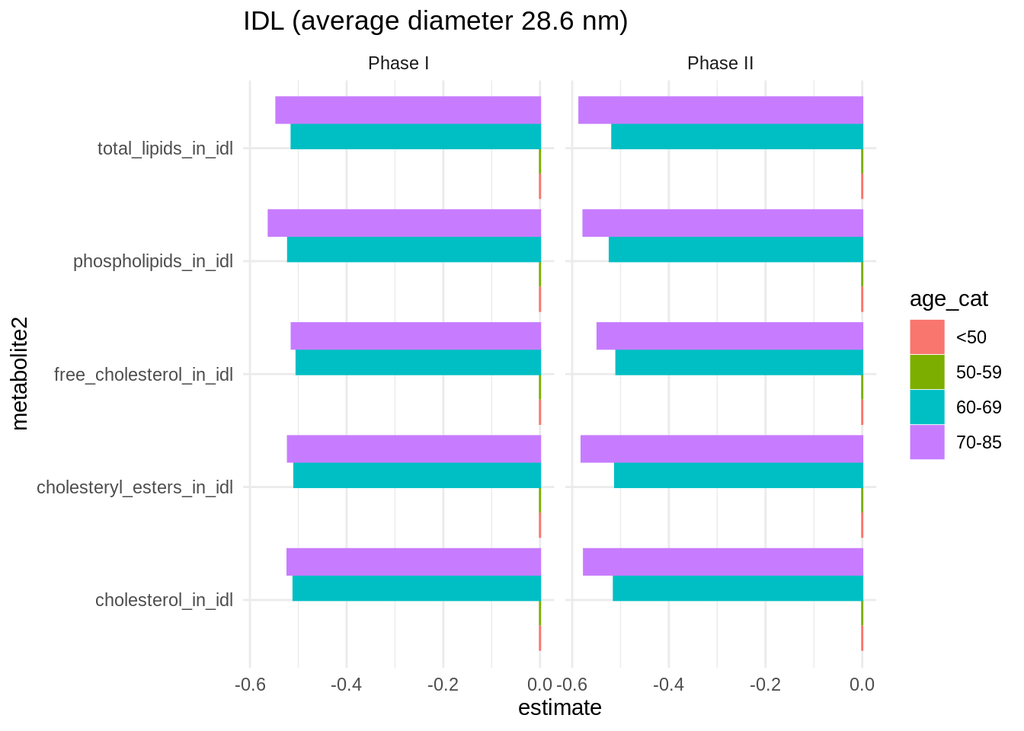

Standardize metabolite (phase 1 and phase 2 separately) Stratify into age groups Fit M1 Combine results across age groups Do FDR correction Identify metabolites with FDRp < 0.05 and Effect size > 0.5 SD Group metabolites into classes Forest plot per metabolite class In the plot, a metabolite is present if at least one of the age strata is significant for the metabolite Bars denote effect size with sign (direction). Show bars only if FDRp < 0.05 for that age strata

# 7 Metabolite class Principle component analysis

For each metabolite class and within age strata, calculate First PC

Test the first PC for each metabolite class with sex in M1 and output p value/FDR p/effect size/SD

## 7.1 M2 Adjusted model

Adjust for:

- Smoking status
- Race (group into white (including british and irish), black, asian, southeast asian, mixed/other)
- BMI mediation analysis (stratified by age) Outcome model: Metabolite ~ Sex (M/F) + BMI + confounders Mediator model: BMI ~ Sex + confounders Use R package `mediation` to obtain the percent of the total effect of Sex on the metabolite that is mediated via BMI

Within each age strata, fit the M2 for all metabolites and get p-values for exposure. Do q-value adjustment, use q <0.05.

## 7.2 M2 Phase II

## 7.3 Summarizing M2 Results

Below I summarize which of the metabolites in Phase I which met the threshold of having BOTH FDR-adjusted pvalue < 0.05 AND an absolute value estimate in the model of >0.5 also met the same threshold criteria in Phase II data.

```
##        Didn't meet threshold Met threshold, not validated
##                          855                           28
##         Validated in Phase 2
##                          113
```

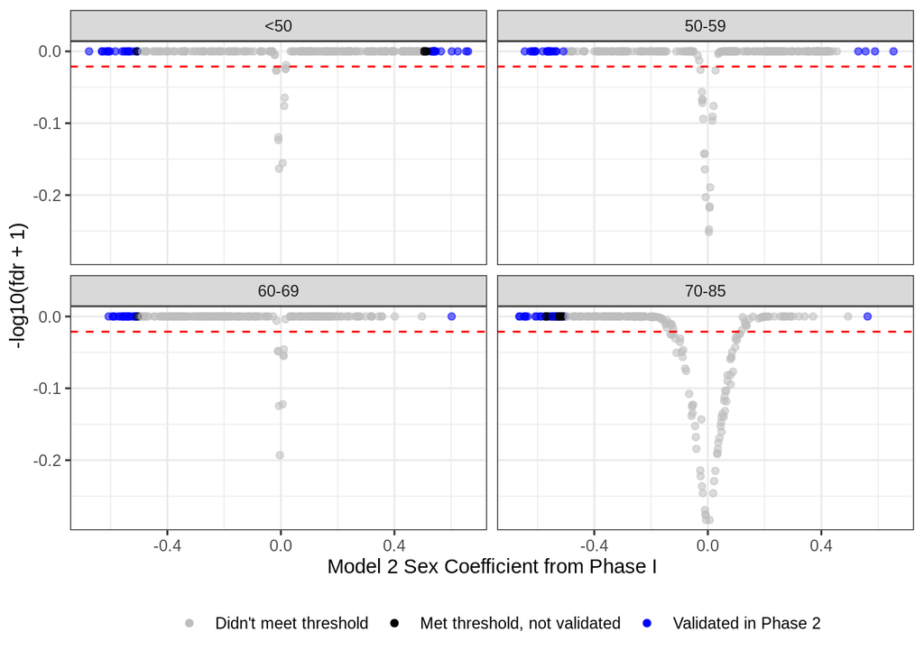

|  | sig_category_m2 Didn’t meet threshold | sig_category_m2 Met threshold, not validated | sig_category_m2 Validated in Phase 2 | Total |  |
| --- | --- | --- | --- | --- | --- |
| age_cat |  |  |  |  |  |
| <50 | 208 | 8 | 33 | 249 |  |
| 50-59 | 225 | 0 | 24 | 249 |  |
| 60-69 | 219 | 3 | 27 | 249 |  |
| 70-85 | 203 | 17 | 29 | 249 |  |
| Total | 855 | 28 | 113 | 996 |  |

number of unique metabolites that met the threshold in Model 2 in Phase I

```
## [1] 68
```

number of unique validated metabolites where the metabolite met the thresholds in Model 2 both phase 1 and phase 2. Saved table of these 57 unique metabolites and their metabolite group and subgroup (validated_unique_mets_m2_57_details.csv).

```
## [1] 57
```

NOW get mx that are sig in both M1 and M2 in Phase I and Phase 2

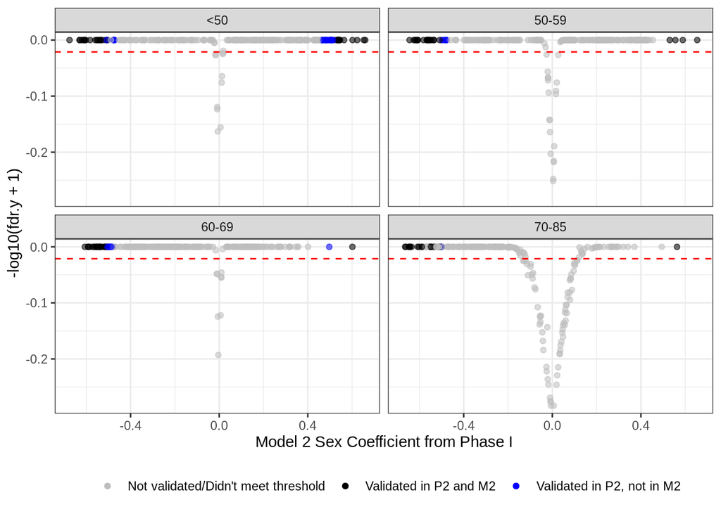

```
## Not validated/Didn't meet threshold              Validated in P2 and M2
##                                 837                                 113
##          Validated in P2, not in M2
##                                  46
```

# 8 Validation

In Phase II data, do same agnostic analysis. How many metabolites are concordant?

- Within each strata, choose metabolites that had q-value <0.05 in Phase I. Look at those metabolites in the Phase II data- run model.
- There will be different sets of metabolites for each strata.
- There will be two sets of validated findings (from M1 and M2).
- Look at magnitude of difference and direction (visualization).

# 9 References

Said MA, Verweij N, van der Harst P. Associations of Combined Genetic and Lifestyle Risks with Incident Cardiovascular Disease and Diabetes in the UK Biobank Study. JAMA Cardiol. 2018;3(8):693-702.